# Arbeiten mit GitHub in RStudio

15.04.2022

## Projektstart

Für die Integration von GitHub mit RStudio-Projekten lassen sich zwei generelle Ansätze unterscheiden. Dabei ist es **zwingend** notwendig, dass es sich um ein RStudio-*Projekt* und nicht nur eine Ansammlung einzelner Script-Dateien handelt, da die Git-Integration nach den durch Projekte erstellten *.rproj*-Dateien ausschau hält.

#### Neues Projekt gestartet auf GitHub

Die in meinen Augen beste und angenehmste Option, da einem automatisch viel der Setup-Arbeit abgenommen wird.  
- Gehe auf GitHub, drücke auf “+” und erstelle dir ein neues Repository  
- Ruf dein erstelltes Repository auf, drück den großen grünen `Code`-Knopf und kopiere dir die dort angezeigte Web-Adresse.  
- Starte in RStudio ein neues Projekt, aber wähle aus dem Menü `Versionskontrolle -> Git` und gib bei `Repository URL` den eben kopierten Link ein. Ich rate aus Gründen der Organisiertheit zusätzlich dazu, sich einen festen Ordner auszusuchen, in dem alle zukünftigen Projekte gespeichert werden sollen, und diesen unter `Create Project as subdirectory of` anzugeben. RStudio wird sich diesen Ordner merken und für das nächste Projekt bereits ausfüllen.

[figure not shown]

URL von GitHub kopieren (links) und in RStudio als Projekt starten (rechts)

Der große Vorteil dieser Reihenfolge ist, dass die ausgewählte GitHub-Repo standardmäßig als `origin` gesehen wird, und lokale Veränderungen den GitHub-Veränderungen folgen. Ohne sich groß mit `Push` und `Pull`-Setup beschäftigen zu müssen, sollte das Projekt mit dieser Methode daher direkt einsatzbereit sein.  
Sollte das von die rausgewählte GitHub-Repository bereits Inhalte aufweisen, so sollten diese im Rahmen des Setups durch RStudio automatisch heruntergeladen werden.

#### Bereits lokal existierendes Projekt

Hast du ein altes Projekt, das du jetzt mit deinem neu erlangten Wissen über GitHub sichern und/oder teilen willst? Dann ist dies der Schritt für dich.  
Die Grundidee ist dabei die selbe wie bei der Erstellung eines neuen Projektes. Wir folgen den oben beschriebenen Schritten, um uns ein neues (leeres) Repo auf GitHub zu stellen, und lokal aus RStudio als neues Projekt anzuwählen.  
Der Kniff hier ist jedoch, dass du nun nach abgeschlossenem Setup des Projektordners einfach dreist hergehen und deine bereits erstellten Dateien über einen Datei-Explorer in den eben erstellten Projektordner verschieben kannst. Die Git-Schnittstelle in RStudio wird die hineinkopierten Dateien als neue Inhalte erkennen und eine Synchronisierung ermöglichen.

## Arbeiten mit Git aus RStudio

Nach dem Start eines Git-Synchronisierten Projektes wird dir vielleicht aufgefallen sein, dass im Environment-Fenster (standardmäßig oben rechts) ein neuer Reiter namens `Git` erschienen ist. Dieses Fenster ist dein bester Freund für das Arbeiten mit Git: Hier kannst du mit nur wenigen Klicks die Arbeit verrichten, die du sonst direkt über Kommandozeilen-Befehle verrichten müsstest. Nicht erschrecken, aber zur Vereinfachung der Erklärung der kommenden Schritte zeige ich dir nun eine Übersichts-Grafik für die grundlegenden Git-Operationen:

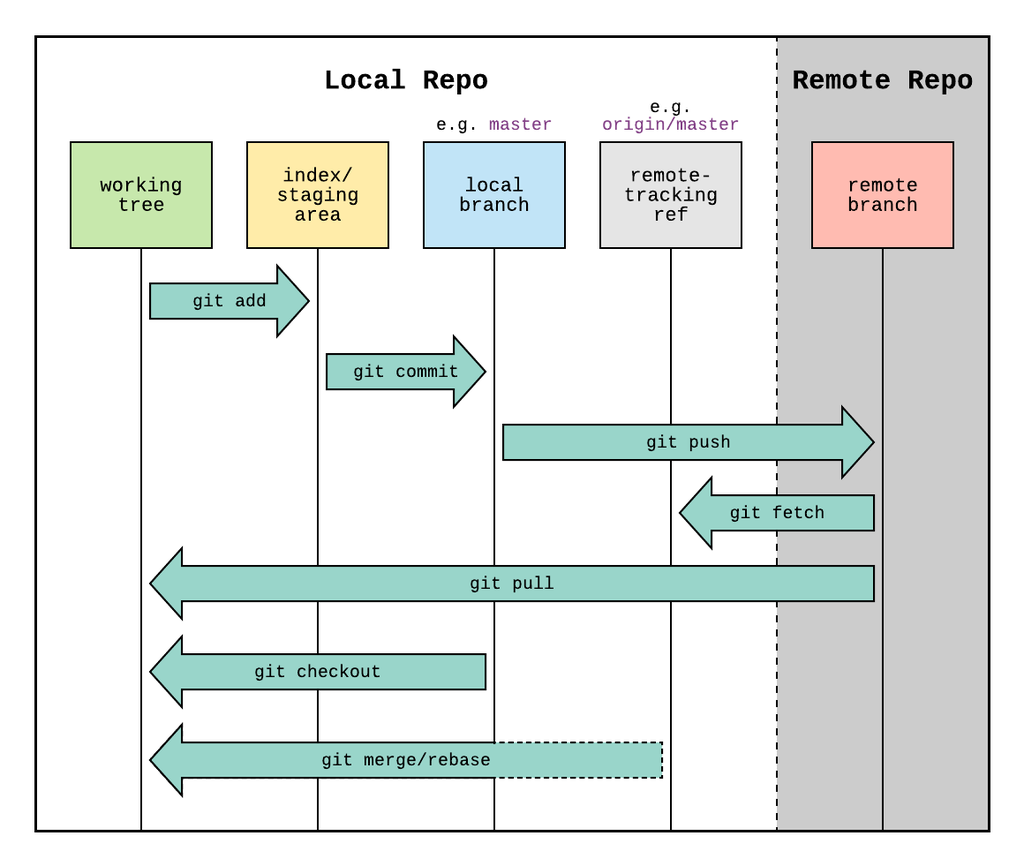

Quelle: [Reddit u/stamminator](https://www.reddit.com/r/git/comments/99ul9f/git_workflow_diagram_showcasing_the_role_of/)  
Mehrere der dort beschriebenen `areas` sollten dir bereits bekannt vorkommen. Der `remote branch` ist dein auf GitHub verfügbares Repository, während der `working tree` der klassische Dateibaum auf deinem lokalen PC ist. Die anderen aufgeführten Ebenen sind nun das, was Git so mächtig macht.  
Nimmst du wie bisher eine Änderung an einem deiner R-Skripte (oder Word-Dokumente, Bilder, …) vor und speicherst diese aus dem Programm heraus ab, verändert sich nur die lokale Datei, und das (meist) irreversibel. Im Kontext von Git ist jedoch das Speichern von Veränderungen nur eine Änderung innerhalb der `working tree`-Ebene, die in der Repo verfügbaren Dateien verändern sich dagegen nicht. Nach dem lokalen Abspeichern einer Veränderung solte die betreffende Datei jedoch im Git-Fenster in RStudio erscheinen. Je nach vorgenommener Modifikation sollte dabei ein entsprechend koloriertes Zeichen neben der Datei stehen: ?(neue Datei), A(dded), M(odified), D(eleted) und R(enamed) werden dabei die am häufigsten auftretenden sein. Dieses Git-Fenster in RStudio lässt sich dabei als Pendant zu der in der Grafik angegebenen `index/staging area` sehen. Hier werden Dateien für die Synchronisierung über Git vorbereitet. Was über die Konsole mit dem Befehl `git add` passiert, lässt sich in RStudio durch das Aktivieren des Hakens neben der entsprechenden Datei einfach umsetzen:

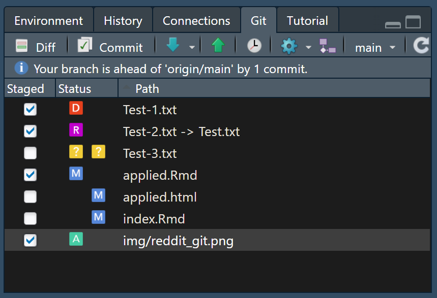

RStudio staging area mit unterschiedlichen Änderungsarten

Um die ausgewählten Dateien nun auch tatsächlich über Git zu speichern, benötigt es noch einen weiteren Schritt: Das Committing. Was sonst auch wieder über den Konsolenbefehl `git commit` passiert, kann aus RStudio auch einfach durch Drücken des `Commit`-Knopfes bewerkstelligt werden.  
**!Wichtig!** Jeder Commit sollte mit einem kurzen Kommentar über die vorgenommenen Änderungen verbunden sein, damit dir selbst in einigen Wochen/Monaten/Jahren noch klar ist, warum genau du diese Änderungen vorgenommen hast.  
Herzlichen Glückwunsch! du hast nun deine Änderungen mit Git als versionskontrollierte Updates abgespeichert. Alles was jetzt noch fehlt, ist die Synchronisierung mit GitHub. Wie du sicher gemerkt hast (und auch im obrigen Bild siehst), merkt RStudio nun an, dass dein lokal abgespeichertes Repository “weiter” entwickelt ist, als der auf GitHub verfügbare Projektzweig (hier origin/main). Um dies zu bereinigen, müssen alle Veränderungen des lokalen Repositories noch zu GitHub “gepusht” werden, was über die Konsole mit `git push` bzw. in RStudio mit dem grünen, nach oben zeigenden Pfeil geschieht. Tu dir dabei nicht den Zwang an, jeden deiner Commits direkt mit GitHub zu synchronisieren. Du kannst durchaus (insbesondere wenn du alleine arbeitest) eine ganze Zeit lang Änderungen vornehmen und committen, bevor du sie mit GitHub synchronisierst.  
Du kannst nun zum Spaß einmal die GitHub-Seite deines Repositories aufrufen und nachschauen, ob deine alle durchgeführten Commits dort gelistet werden. Arbeitest du mit mehreren PCs am selben Projekt, so kannst du alle durchgeführten Änderungen an diesen PCs per `git pull` bzw. dem türkisen Pfeil in RStudio synchronisieren.

## Was nun?

Du kennst nun die grundlegende Funktionsweise von Git und GitHub und weißt, wie du sie aus RStudio zur Versionskontrolle benutzen kannst.  
DIe Nutzung von Git ermöglicht dir zusätzlich noch eine ganze Reihe weiterer Möglichkeiten. So kannst du beispielsweise mit mehreren anderen Nutzern an demselben Projekt arbeiten, und deine und ihre Commits einfach synchronisieren. Außerdem bietet Git dir die Möglichkeit, ein einzelnen Programm in mehreren `branches` zu entwickeln, sodass du beispielsweise eine stabile Version deines Codes öffentlich anderen Nutzern verfügbar machen kannst, während du in einem anderen Branch experimentell mit neuen Ideen und Inhalten experimentierst. Diese Branches lassen sich bei abgeschlossenem Experiment jederzeit miteinander zusammenführen, die genaue Durchführung dieser und anderer Nutzungsmethoden sprengt jedoch den Rahmen dieser kurzen Einführung.  
Ich wünsche viel Erfolg in der Nutzung von Git und Happy Coding!

Für eine gründlichere Beleuchtung der Nutzung von R mit Git und GitHub verweise ich gerne auf: https://happygitwithr.com/index.html  
Bei Fragen und je nach Schwere der auftretenden Probleme kann ich auch im Tutorium zu Helfen versuchen. Ich habe zwar alle hier aufgeführten Schritte auf meiner Maschine getestet, das ist jedoch keine Funktionsgarantie.